# Practical Machine Learning with R and Python - Part 3

Tinniam V Ganesh

October 16, 2017

In this post ‘Practical Machine Learning with R and Python - Part 3’ I discuss ‘Feature Selection’ methods. This post is a continuation of my 2 earlier posts

1.[Practical Machine Learning with R and Python - Part 1](https://gigadom.wordpress.com/2017/10/06/practical-machine-learning-with-r-and-python-part-1/) 2.[Practical Machine Learning with R and Python - Part 1](https://gigadom.wordpress.com/2017/10/13/practical-machine-learning-with-r-and-python-part-2/)

Usually there will be a large number of predictors for a target variable. It is likely that not all the predictor or feature variables will have an impact on the output. Hence it is becomes necessary to choose all those features which influence the output variable. The techiniques that are used to simplify the machine learning model while removing features which have little or no impact are

- Best fit
- Forward fit
- Backward fit
- Ridge Regression or L2 regularization
- Lasso or L1 regularization

All these methods remove those features which do not have a great influence on the output. # 1.1 Best Fit For a dataset with features f1,f2,f3…fn, the best fit chooses all combinations of features and creates separate ML models for each of the combinations. The best fit algotithm then uses some filtering criteria based on Adj Rsquared, Cp or AIC to pick out the best model among all models. Since the Best Fit approach searches the entire solumn space it is computationally infeasible. The number of models that have to be searched work to $latex 2^{p}$. This can be shown as follows

There are $latex C_{1}$ ways to choose single feature ML models among n features, $latex C_{2}$ ways to choose 2 feature models among n models and so on, or

$C_{1} + C_{2} +.... + C_{n}$= Total number of models in Best Fit Since $ (1+x)^{n} = 1+C_{1}x + C_{2} +… + C_{n}$ and when x=1 this becomes $2^{n} = 1+C_{1}x + C_{2} +... + C_{n}$

Hence there are $2^{n}$ models to search amongs in Best Fit. For 10 features this is 1000 models and for 40 features this becoms $2^{40}$ which almost 1 trillion. Usually there are datasets with 1000 or maybe even 100000 features and Best fit becomes computationally infeasible.

Anyways I have included the Best Fit approach as I use the Boston crime datasets which is available both the MASS package in R and Sklearn in Python.

Perform a simple Linear Regression Fit. By looking at the p-values of the features it can be seen that ‘indus’ and ‘age’ features have high p-values and are not significant

# 1.1a Linear Regression - R code

```r
source('RFunctions-1.R')
#Read the Boston crime data
df=read.csv("Boston.csv",stringsAsFactors = FALSE) # Data from MASS - SL
# Rename the columns
names(df) <-c("no","crimeRate","zone","indus","charles","nox","rooms","age",
              "distances","highways","tax","teacherRatio","color","status","cost")
# Select specific columns
df1 <- df %>% dplyr::select("crimeRate","zone","indus","charles","nox","rooms","age",
                            "distances","highways","tax","teacherRatio","color","status","cost")
dim(df1)
```

```
## [1] 506  14
```

```r
# Linear Regression fit
fit <- lm(cost~. ,data=df1)
summary(fit)
```

```
##
## Call:
## lm(formula = cost ~ ., data = df1)
##
## Residuals:
##     Min      1Q  Median      3Q     Max
## -15.595  -2.730  -0.518   1.777  26.199
##
## Coefficients:
##                Estimate Std. Error t value Pr(>|t|)
## (Intercept)   3.646e+01  5.103e+00   7.144 3.28e-12 ***
## crimeRate    -1.080e-01  3.286e-02  -3.287 0.001087 **
## zone          4.642e-02  1.373e-02   3.382 0.000778 ***
## indus         2.056e-02  6.150e-02   0.334 0.738288
## charles       2.687e+00  8.616e-01   3.118 0.001925 **
## nox          -1.777e+01  3.820e+00  -4.651 4.25e-06 ***
## rooms         3.810e+00  4.179e-01   9.116  < 2e-16 ***
## age           6.922e-04  1.321e-02   0.052 0.958229
## distances    -1.476e+00  1.995e-01  -7.398 6.01e-13 ***
## highways      3.060e-01  6.635e-02   4.613 5.07e-06 ***
## tax          -1.233e-02  3.760e-03  -3.280 0.001112 **
## teacherRatio -9.527e-01  1.308e-01  -7.283 1.31e-12 ***
## color         9.312e-03  2.686e-03   3.467 0.000573 ***
## status       -5.248e-01  5.072e-02 -10.347  < 2e-16 ***
## ---
## Signif. codes:  0 '***' 0.001 '**' 0.01 '*' 0.05 '.' 0.1 ' ' 1
##
## Residual standard error: 4.745 on 492 degrees of freedom
## Multiple R-squared:  0.7406, Adjusted R-squared:  0.7338
## F-statistic: 108.1 on 13 and 492 DF,  p-value: < 2.2e-16
```

# 1.1a Best Fit - R code

The Best Fit requires the ‘leaps’ R package

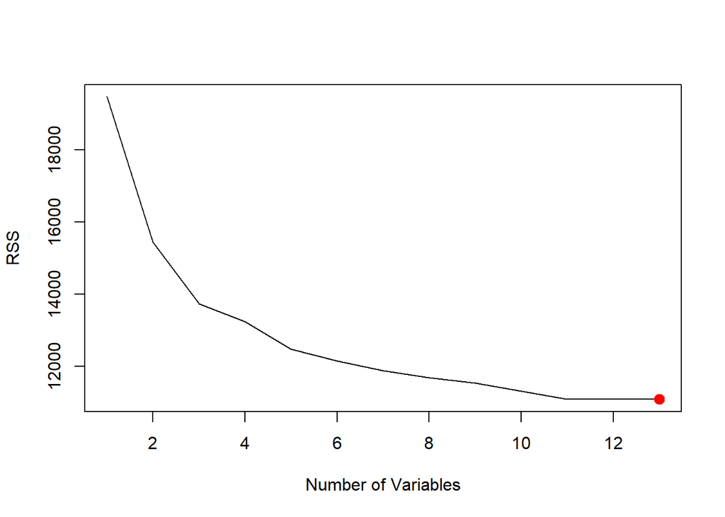

```r
library(leaps)
source('RFunctions-1.R')
#Read the Boston crime data
df=read.csv("Boston.csv",stringsAsFactors = FALSE) # Data from MASS - SL
# Rename the columns
names(df) <-c("no","crimeRate","zone","indus","charles","nox","rooms","age",
              "distances","highways","tax","teacherRatio","color","status","cost")
# Select specific columns
df1 <- df %>% dplyr::select("crimeRate","zone","indus","charles","nox","rooms","age",
                            "distances","highways","tax","teacherRatio","color","status","cost")

# Perform a best fit
bestFit=regsubsets(cost~.,df1,nvmax=13)

# Generate a summary of the fit
bfSummary=summary(bestFit)

# Plot the Residual Sum of Squares vs number of variables
plot(bfSummary$rss,xlab="Number of Variables",ylab="RSS",type="l")
# Get the index of the minimum value
a=which.min(bfSummary$rss)
# Mark this in red
points(a,bfSummary$rss[a],col="red",cex=2,pch=20)
```

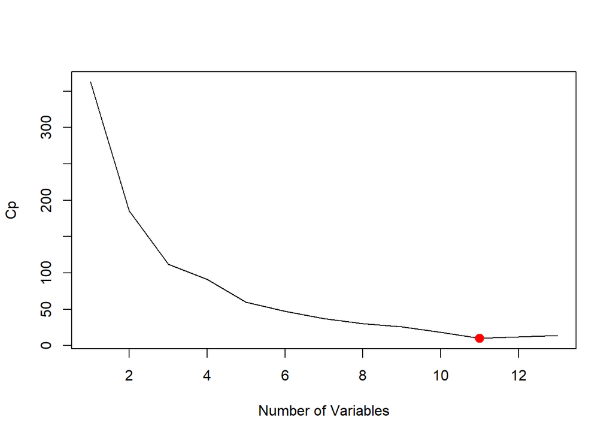

```r
# Plot the CP statistic vs Number of variables
plot(bfSummary$cp,xlab="Number of Variables",ylab="Cp",type='l')
# Find the lowest CP value
b=which.min(bfSummary$cp)
# Mark this in red
points(b,bfSummary$cp[b],col="red",cex=2,pch=20)
```

```r
# Display the set of features which provide the best fit
coef(bestFit,b)
```

```
##   (Intercept)     crimeRate          zone       charles           nox
##  36.341145004  -0.108413345   0.045844929   2.718716303 -17.376023429
##         rooms     distances      highways           tax  teacherRatio
##   3.801578840  -1.492711460   0.299608454  -0.011777973  -0.946524570
##         color        status
##   0.009290845  -0.522553457
```

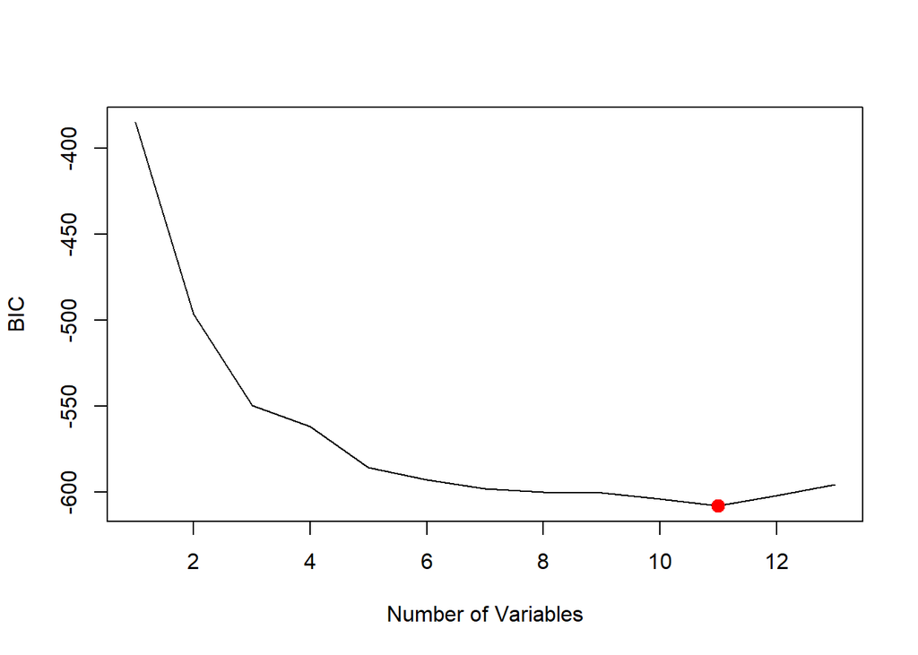

```r
#  Plot the BIC value
plot(bfSummary$bic,xlab="Number of Variables",ylab="BIC",type='l')
# Find and mark the min value
c=which.min(bfSummary$bic)
points(c,bfSummary$bic[c],col="red",cex=2,pch=20)
```

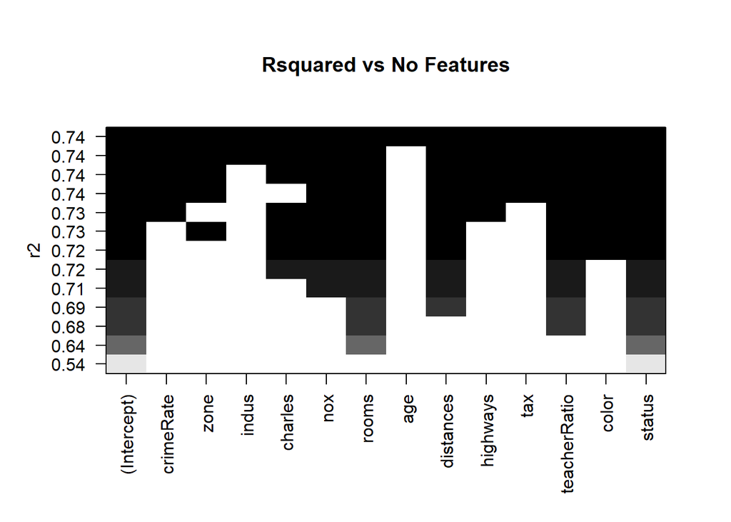

```r
# R has some other good plots for best fit
plot(bestFit,scale="r2",main="Rsquared vs No Features")
```

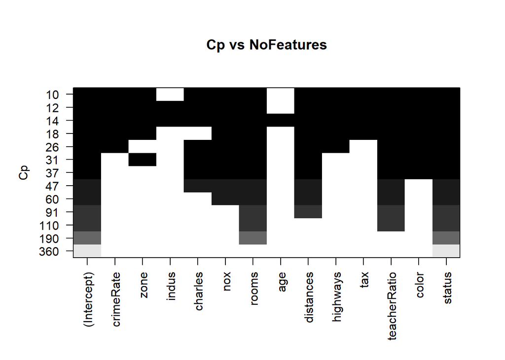

```r
plot(bestFit,scale="Cp",main="Cp vs NoFeatures")
```

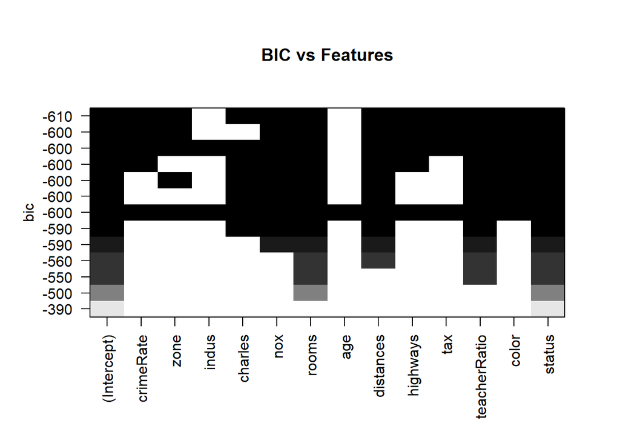

```r
plot(bestFit,scale="bic",main="BIC vs Features")
```